# INN Hotels Project

## Context

A significant number of hotel bookings are called-off due to cancellations or no-shows. The typical reasons for cancellations include change of plans, scheduling conflicts, etc. This is often made easier by the option to do so free of charge or preferably at a low cost which is beneficial to hotel guests but it is a less desirable and possibly revenue-diminishing factor for hotels to deal with. Such losses are particularly high on last-minute cancellations.

The new technologies involving online booking channels have dramatically changed customers’ booking possibilities and behavior. This adds a further dimension to the challenge of how hotels handle cancellations, which are no longer limited to traditional booking and guest characteristics.

The cancellation of bookings impact a hotel on various fronts:

- Loss of resources (revenue) when the hotel cannot resell the room.
- Additional costs of distribution channels by increasing commissions or paying for publicity to help sell these rooms.
- Lowering prices last minute, so the hotel can resell a room, resulting in reducing the profit margin.
- Human resources to make arrangements for the guests.

## Objective

The increasing number of cancellations calls for a Machine Learning based solution that can help in predicting which booking is likely to be canceled. INN Hotels Group has a chain of hotels in Portugal, they are facing problems with the high number of booking cancellations and have reached out to your firm for data-driven solutions. You as a data scientist have to analyze the data provided to find which factors have a high influence on booking cancellations, build a predictive model that can predict which booking is going to be canceled in advance, and help in formulating profitable policies for cancellations and refunds.

## Data Description

The data contains the different attributes of customers' booking details. The detailed data dictionary is given below.

**Data Dictionary**

- Booking_ID: unique identifier of each booking
- no_of_adults: Number of adults
- no_of_children: Number of Children
- no_of_weekend_nights: Number of weekend nights (Saturday or Sunday) the guest stayed or booked to stay at the hotel
- no_of_week_nights: Number of week nights (Monday to Friday) the guest stayed or booked to stay at the hotel
- type_of_meal_plan: Type of meal plan booked by the customer:
  - Not Selected – No meal plan selected
  - Meal Plan 1 – Breakfast
  - Meal Plan 2 – Half board (breakfast and one other meal)
  - Meal Plan 3 – Full board (breakfast, lunch, and dinner)
- required_car_parking_space: Does the customer require a car parking space? (0 - No, 1- Yes)
- room_type_reserved: Type of room reserved by the customer. The values are ciphered (encoded) by INN Hotels.
- lead_time: Number of days between the date of booking and the arrival date
- arrival_year: Year of arrival date
- arrival_month: Month of arrival date
- arrival_date: Date of the month
- market_segment_type: Market segment designation.
- repeated_guest: Is the customer a repeated guest? (0 - No, 1- Yes)
- no_of_previous_cancellations: Number of previous bookings that were canceled by the customer prior to the current booking
- no_of_previous_bookings_not_canceled: Number of previous bookings not canceled by the customer prior to the current booking
- avg_price_per_room: Average price per day of the reservation; prices of the rooms are dynamic. (in euros)
- no_of_special_requests: Total number of special requests made by the customer (e.g. high floor, view from the room, etc)
- booking_status: Flag indicating if the booking was canceled or not.

## Importing necessary libraries and data

```python
# Installing the libraries with the specified version.
!pip install pandas==1.5.3 numpy==1.25.2 matplotlib==3.7.1 seaborn==0.13.1 scikit-learn==1.2.2 statsmodels==0.14.1 -q --user
```

[output not shown]

**Note**: *After running the above cell, kindly restart the notebook kernel and run all cells sequentially from the start again.*

```python
import pandas as pd
import numpy as np

# for visualizing data
import matplotlib.pyplot as plt
import seaborn as sns

# For randomized data splitting
from sklearn.model_selection import train_test_split, GridSearchCV, StratifiedKFold # Import GridSearchCV and StratifiedKFold

# Removing the limit for displayed columns
pd.set_option("display.max_columns", None)
# Setting the limit for displayed rows
pd.set_option("display.max_rows", 200)


# For building models for prediction
import statsmodels.stats.api as sms
from statsmodels.stats.outliers_influence import variance_inflation_factor
import statsmodels.api as sm
from statsmodels.tools.tools import add_constant
from sklearn.linear_model import LogisticRegression
from sklearn.tree import DecisionTreeClassifier # Import DecisionTreeClassifier
from sklearn import tree # Import the tree module for plotting


# Calling different metric scores
from sklearn.metrics import (
    f1_score,
    accuracy_score,
    recall_score,
    precision_score,
    confusion_matrix,
    roc_auc_score,
    ConfusionMatrixDisplay,
    precision_recall_curve,
    roc_curve,
    make_scorer # Import make_scorer
)
```

## Loading the Dataset

```python
# Accessing folder from google.colab drive
from google.colab import drive
drive.mount('/content/drive/')

# Opening csv data file
df = pd.read_csv('/content/drive/MyDrive/Content/INNHotelsGroup.csv')
```

## Data Overview

- Observations
- Sanity checks

```python
# Checking first 5 rows of dataset
df.head()
```

|  | Booking_ID | no_of_adults | no_of_children | no_of_weekend_nights | no_of_week_nights | type_of_meal_plan | required_car_parking_space | room_type_reserved | lead_time | arrival_year | arrival_month | arrival_date | market_segment_type | repeated_guest | no_of_previous_cancellations | no_of_previous_bookings_not_canceled | avg_price_per_room | no_of_special_requests | booking_status |
| --- | --- | --- | --- | --- | --- | --- | --- | --- | --- | --- | --- | --- | --- | --- | --- | --- | --- | --- | --- |
| 0 | INN00001 | 2 | 0 | 1 | 2 | Meal Plan 1 | 0 | Room_Type 1 | 224 | 2017 | 10 | 2 | Offline | 0 | 0 | 0 | 65.00 | 0 | Not_Canceled |
| 1 | INN00002 | 2 | 0 | 2 | 3 | Not Selected | 0 | Room_Type 1 | 5 | 2018 | 11 | 6 | Online | 0 | 0 | 0 | 106.68 | 1 | Not_Canceled |
| 2 | INN00003 | 1 | 0 | 2 | 1 | Meal Plan 1 | 0 | Room_Type 1 | 1 | 2018 | 2 | 28 | Online | 0 | 0 | 0 | 60.00 | 0 | Canceled |
| 3 | INN00004 | 2 | 0 | 0 | 2 | Meal Plan 1 | 0 | Room_Type 1 | 211 | 2018 | 5 | 20 | Online | 0 | 0 | 0 | 100.00 | 0 | Canceled |
| 4 | INN00005 | 2 | 0 | 1 | 1 | Not Selected | 0 | Room_Type 1 | 48 | 2018 | 4 | 11 | Online | 0 | 0 | 0 | 94.50 | 0 | Canceled |

```python
# Checking the last 5 rows of dataset
df.tail()
```

|  | Booking_ID | no_of_adults | no_of_children | no_of_weekend_nights | no_of_week_nights | type_of_meal_plan | required_car_parking_space | room_type_reserved | lead_time | arrival_year | arrival_month | arrival_date | market_segment_type | repeated_guest | no_of_previous_cancellations | no_of_previous_bookings_not_canceled | avg_price_per_room | no_of_special_requests | booking_status |
| --- | --- | --- | --- | --- | --- | --- | --- | --- | --- | --- | --- | --- | --- | --- | --- | --- | --- | --- | --- |
| 36270 | INN36271 | 3 | 0 | 2 | 6 | Meal Plan 1 | 0 | Room_Type 4 | 85 | 2018 | 8 | 3 | Online | 0 | 0 | 0 | 167.80 | 1 | Not_Canceled |
| 36271 | INN36272 | 2 | 0 | 1 | 3 | Meal Plan 1 | 0 | Room_Type 1 | 228 | 2018 | 10 | 17 | Online | 0 | 0 | 0 | 90.95 | 2 | Canceled |
| 36272 | INN36273 | 2 | 0 | 2 | 6 | Meal Plan 1 | 0 | Room_Type 1 | 148 | 2018 | 7 | 1 | Online | 0 | 0 | 0 | 98.39 | 2 | Not_Canceled |
| 36273 | INN36274 | 2 | 0 | 0 | 3 | Not Selected | 0 | Room_Type 1 | 63 | 2018 | 4 | 21 | Online | 0 | 0 | 0 | 94.50 | 0 | Canceled |
| 36274 | INN36275 | 2 | 0 | 1 | 2 | Meal Plan 1 | 0 | Room_Type 1 | 207 | 2018 | 12 | 30 | Offline | 0 | 0 | 0 | 161.67 | 0 | Not_Canceled |

```python
# Checking shape of dataset
print("There are", df.shape[0], "rows and", df.shape[1], "columns in the dataset.")
```

```
There are 36275 rows and 19 columns in the dataset.
```

```python
# Checking the data types of columns in dataset
df.info()
```

```
<class 'pandas.core.frame.DataFrame'>
RangeIndex: 36275 entries, 0 to 36274
Data columns (total 19 columns):
 #   Column                                Non-Null Count  Dtype
---  ------                                --------------  -----
 0   Booking_ID                            36275 non-null  object
 1   no_of_adults                          36275 non-null  int64
 2   no_of_children                        36275 non-null  int64
 3   no_of_weekend_nights                  36275 non-null  int64
 4   no_of_week_nights                     36275 non-null  int64
 5   type_of_meal_plan                     36275 non-null  object
 6   required_car_parking_space            36275 non-null  int64
 7   room_type_reserved                    36275 non-null  object
 8   lead_time                             36275 non-null  int64
 9   arrival_year                          36275 non-null  int64
 10  arrival_month                         36275 non-null  int64
 11  arrival_date                          36275 non-null  int64
 12  market_segment_type                   36275 non-null  object
 13  repeated_guest                        36275 non-null  int64
 14  no_of_previous_cancellations          36275 non-null  int64
 15  no_of_previous_bookings_not_canceled  36275 non-null  int64
 16  avg_price_per_room                    36275 non-null  float64
 17  no_of_special_requests                36275 non-null  int64
 18  booking_status                        36275 non-null  object
dtypes: float64(1), int64(13), object(5)
memory usage: 5.3+ MB
```

```python
# Checking for missing values in the data
df.isnull().sum()
```

|  | 0 |
| --- | --- |
| Booking_ID | 0 |
| no_of_adults | 0 |
| no_of_children | 0 |
| no_of_weekend_nights | 0 |
| no_of_week_nights | 0 |
| type_of_meal_plan | 0 |
| required_car_parking_space | 0 |
| room_type_reserved | 0 |
| lead_time | 0 |
| arrival_year | 0 |
| arrival_month | 0 |
| arrival_date | 0 |
| market_segment_type | 0 |
| repeated_guest | 0 |
| no_of_previous_cancellations | 0 |
| no_of_previous_bookings_not_canceled | 0 |
| avg_price_per_room | 0 |
| no_of_special_requests | 0 |
| booking_status | 0 |

**dtype:** int64

- There are no missing values in the dataset.

```python
# Checking for duplicates
df.duplicated().sum()
```

```
np.int64(0)
```

- There are no duplicates in the dataset.

```python
# Getting a statistical summary
df.describe().T
```

|  | count | mean | std | min | 25% | 50% | 75% | max |
| --- | --- | --- | --- | --- | --- | --- | --- | --- |
| no_of_adults | 36275.0 | 1.844962 | 0.518715 | 0.0 | 2.0 | 2.00 | 2.0 | 4.0 |
| no_of_children | 36275.0 | 0.105279 | 0.402648 | 0.0 | 0.0 | 0.00 | 0.0 | 10.0 |
| no_of_weekend_nights | 36275.0 | 0.810724 | 0.870644 | 0.0 | 0.0 | 1.00 | 2.0 | 7.0 |
| no_of_week_nights | 36275.0 | 2.204300 | 1.410905 | 0.0 | 1.0 | 2.00 | 3.0 | 17.0 |
| required_car_parking_space | 36275.0 | 0.030986 | 0.173281 | 0.0 | 0.0 | 0.00 | 0.0 | 1.0 |
| lead_time | 36275.0 | 85.232557 | 85.930817 | 0.0 | 17.0 | 57.00 | 126.0 | 443.0 |
| arrival_year | 36275.0 | 2017.820427 | 0.383836 | 2017.0 | 2018.0 | 2018.00 | 2018.0 | 2018.0 |
| arrival_month | 36275.0 | 7.423653 | 3.069894 | 1.0 | 5.0 | 8.00 | 10.0 | 12.0 |
| arrival_date | 36275.0 | 15.596995 | 8.740447 | 1.0 | 8.0 | 16.00 | 23.0 | 31.0 |
| repeated_guest | 36275.0 | 0.025637 | 0.158053 | 0.0 | 0.0 | 0.00 | 0.0 | 1.0 |
| no_of_previous_cancellations | 36275.0 | 0.023349 | 0.368331 | 0.0 | 0.0 | 0.00 | 0.0 | 13.0 |
| no_of_previous_bookings_not_canceled | 36275.0 | 0.153411 | 1.754171 | 0.0 | 0.0 | 0.00 | 0.0 | 58.0 |
| avg_price_per_room | 36275.0 | 103.423539 | 35.089424 | 0.0 | 80.3 | 99.45 | 120.0 | 540.0 |
| no_of_special_requests | 36275.0 | 0.619655 | 0.786236 | 0.0 | 0.0 | 0.00 | 1.0 | 5.0 |

## Exploratory Data Analysis (EDA)

- EDA is an important part of any project involving data.
- It is important to investigate and understand the data better before building a model with it.
- A few questions have been mentioned below which will help you approach the analysis in the right manner and generate insights from the data.
- A thorough analysis of the data, in addition to the questions mentioned below, should be done.

## **Leading Questions**

**1. What are the busiest months in the hotel?**

```python
# Creating a column for month names for readability
df['month_name'] = pd.to_datetime(df['arrival_month'], format='%m').dt.strftime('%b')
```

```python
# Getting counts by month
print(df['month_name'].value_counts())
```

```
month_name
Oct    5317
Sep    4611
Aug    3813
Jun    3203
Dec    3021
Nov    2980
Jul    2920
Apr    2736
May    2598
Mar    2358
Feb    1704
Jan    1014
Name: count, dtype: int64
```

```python
# Getting percentage of counts by month
print(df['month_name'].value_counts(normalize=True))
```

```
month_name
Oct    0.146575
Sep    0.127112
Aug    0.105114
Jun    0.088298
Dec    0.083280
Nov    0.082150
Jul    0.080496
Apr    0.075424
May    0.071620
Mar    0.065003
Feb    0.046975
Jan    0.027953
Name: proportion, dtype: float64
```

- The busiest months are October(5,317 bookings or 14.6% of bookings) followed by September(4,611 bookings or 12.7%) and August(3,813 bookings or 10.5%).
- The slowest months are January(1,014 bookings or 2.8%) followed by February with 1,704 bookings(4.7%) and March with 2,358 bookings(6.5%).

**2. Which market segment do most of the guests come from?**

```python
# Getting counts by market segment type
print(df['market_segment_type'].value_counts())
```

```
market_segment_type
Online           23214
Offline          10528
Corporate         2017
Complementary      391
Aviation           125
Name: count, dtype: int64
```

```python
# Getting percentage of market segment types
print(df['market_segment_type'].value_counts(normalize=True))
```

```
market_segment_type
Online           0.639945
Offline          0.290227
Corporate        0.055603
Complementary    0.010779
Aviation         0.003446
Name: proportion, dtype: float64
```

- Most of the guests(at 63.9%) come from the Online market segment.
- The least popular market segment type is Aviation at 0.3%.

**3. Hotel rates are dynamic and change according to demand and customer demographics. What are the differences in room prices in different market segments?**

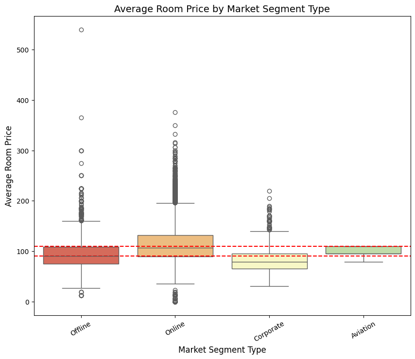

```python
# Filtering out the 'Complementary' market segment type
df_filtered = df[df['market_segment_type'] != 'Complementary']

# Seting the figure size
plt.figure(figsize=(10, 8))

# Using the 'Spectral' color palette
palette = sns.color_palette("Spectral", n_colors=df['market_segment_type'].nunique())

# Creating the boxplot
sns.boxplot(data=df_filtered, x='market_segment_type', y='avg_price_per_room', palette=palette)

# Add red horizontal lines at y=90 and y=110
plt.axhline(y=90, color='red', linestyle='--', linewidth=1.5)
plt.axhline(y=110, color='red', linestyle='--', linewidth=1.5)

# Customize labels and title
plt.xlabel('Market Segment Type', fontsize=12)
plt.ylabel('Average Room Price', fontsize=12)
plt.title('Average Room Price by Market Segment Type', fontsize=14)

# Rotate x labels for readability if needed
plt.xticks(rotation=30)

plt.show()
```

- Online market segment types consistently book the most expensive rooms on average with 50% of bookings costing 90 to 130 euros.
- The Corporate market segment types consistently book the least expensive rooms with 50% of bookings costing 70 to 95 euros.

**4. What percentage of bookings are canceled?**

```python
# Getting percentage of bookings canceled
cancel_rate = (df['booking_status'].eq('Canceled').mean()) * 100
print(f"Percentage of bookings canceled: {cancel_rate:.2f}%")
```

```
Percentage of bookings canceled: 32.76%
```

- 32.76% of bookings are canceled.

**5. Repeating guests are the guests who stay in the hotel often and are important to brand equity. What percentage of repeating guests cancel?**

```python
# Filtering only repeating guests
repeat_guests = df[df['repeated_guest'] == 1]

# Calculating how many of them canceled
num_canceled = repeat_guests[repeat_guests['booking_status'] == 'Canceled'].shape[0]

# Calculating total number of repeat guests
total_repeat = repeat_guests.shape[0]

# Finding percentage
percentage_canceled = (num_canceled / total_repeat) * 100

print(percentage_canceled)
```

```
1.7204301075268817
```

- 1.7% of repeating guests canceled their booking.

**6. Many guests have special requirements when booking a hotel room. Do these requirements affect booking cancellation?**

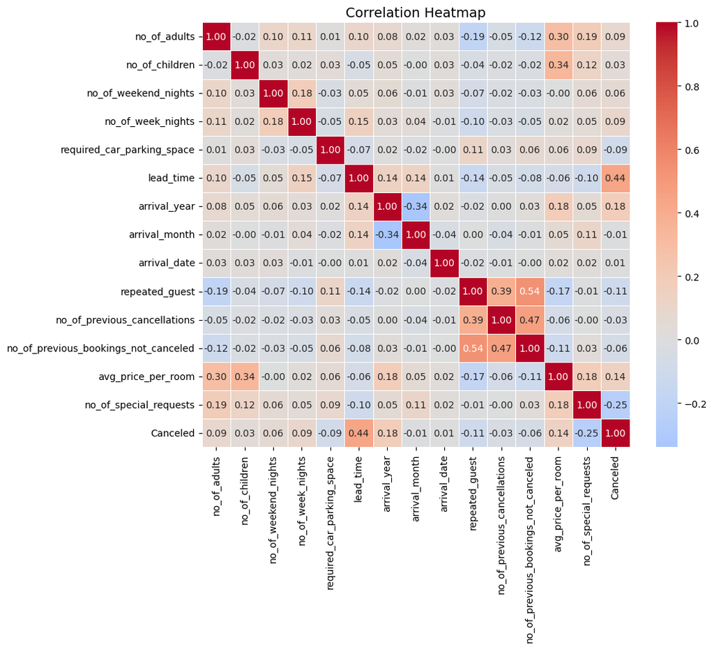

```python
"""df2 will convert Canceled to 1 and Not_Canceled to 0"""

# Creating a copy to manipulate
df2 = df.copy()

# Converting Canceled/Not_Canceled into 1 and 0 and putting in column 'Canceled'
df2['Canceled'] = df2['booking_status'].map({'Canceled': 1, 'Not_Canceled': 0})


# Creating a correlation matrix
corr = df2.corr(numeric_only=True)

# Plot heatmap with diverging color scale
plt.figure(figsize=(10, 8))
sns.heatmap(
    corr,
    cmap='coolwarm',   # blue = negative, red = positive
    annot=True,
    fmt='.2f',
    linewidths=0.5,
    center=0            # ensures 0 correlation is white/neutral
)

plt.title('Correlation Heatmap', fontsize=14)
plt.show()
```

- `no_of_special_requests` is negatively correlated to canceled bookings suggesting guests with higher numbers of special requests are less likely to cancel.
- It also looks like `lead_time` has a moderately positive correlation with Canceled. This suggests greater lead times increase the chances of canceled bookings.
- `avg_price_per_room` is somewhat positively correlated with `no_of_children` and `no_of_adults`.

### **Univariate Analysis**

```python
def histogram_boxplot(data, feature, figsize=(15, 10), kde=False, bins=None):
    """
    Boxplot and histogram combined

    data: dataframe
    feature: dataframe column
    figsize: size of figure (default (15,10))
    kde: whether to show the density curve (default False)
    bins: number of bins for histogram (default None)
    """
    f2, (ax_box2, ax_hist2) = plt.subplots(
        nrows=2,  # Number of rows of the subplot grid= 2
        sharex=True,  # x-axis will be shared among all subplots
        gridspec_kw={"height_ratios": (0.25, 0.75)},
        figsize=figsize,
    )  # creating the 2 subplots
    sns.boxplot(
        data=df, x=feature, ax=ax_box2, showmeans=True, color="violet"
    )  # boxplot will be created and a triangle will indicate the mean value of the column
    sns.histplot(
        data=df, x=feature, kde=kde, ax=ax_hist2, bins=bins
    ) if bins else sns.histplot(
        data=data, x=feature, kde=kde, ax=ax_hist2
    )  # For histogram
    ax_hist2.axvline(
        df2[feature].mean(), color="green", linestyle="--"
    )  # Add mean to the histogram
    ax_hist2.axvline(
        data[feature].median(), color="black", linestyle="-"
    )  # Add median to the histogram
```

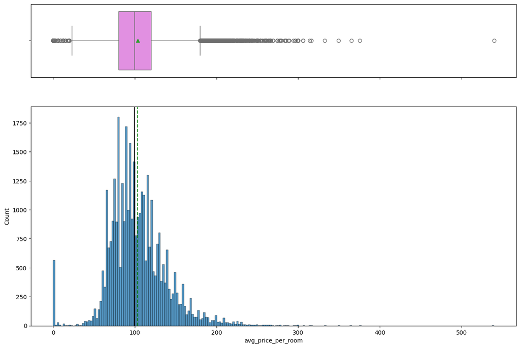

```python
# Calling boxplot and histogram of avg_price_per_room
histogram_boxplot(df2, 'avg_price_per_room')
```

**Observations**

- The `avg_price_per_room` is right skewed with an outlier close to 530 euros.
- Some of the rooms are priced way above others with the median at about 100 euros.

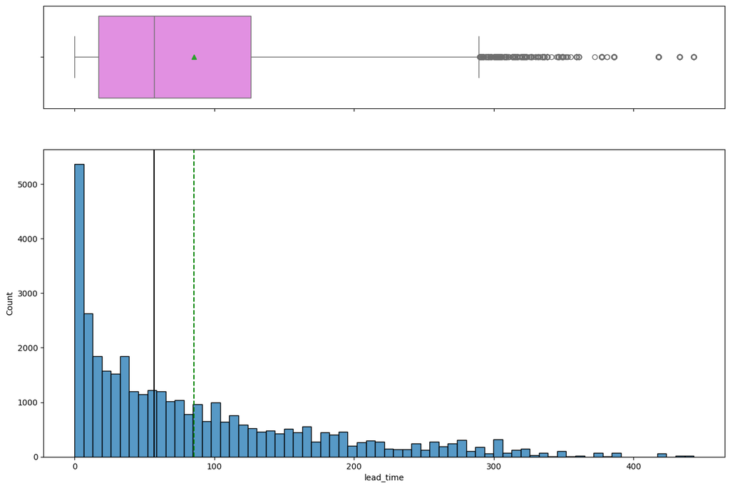

```python
# Calling boxplot and histogram of lead_time
histogram_boxplot(df2, 'lead_time')
```

**Observations**

```python
# Function to create labeled barplots
def labeled_barplot(data, feature, perc=False, n=None):
    """
    Barplot with percentage at the top

    data: dataframe
    feature: dataframe column
    perc: whether to display percentages instead of count (default is False)
    n: displays the top n category levels (default is None, i.e., display all levels)
    """

    total = len(data[feature])  # length of the column
    count = data[feature].nunique()
    if n is None:
        plt.figure(figsize=(count + 2, 6))
    else:
        plt.figure(figsize=(n + 2, 6))

    plt.xticks(rotation=90, fontsize=15)
    ax = sns.countplot(
        data=data,
        x=feature,
        palette="Paired",
        order=data[feature].value_counts().index[:n],
    )

    for p in ax.patches:
        if perc == True:
            label = "{:.1f}%".format(
                100 * p.get_height() / total
            )  # percentage of each class of the category
        else:
            label = p.get_height()  # count of each level of the category

        x = p.get_x() + p.get_width() / 2  # width of the plot
        y = p.get_height()  # height of the plot

        ax.annotate(
            label,
            (x, y),
            ha="center",
            va="center",
            size=12,
            xytext=(0, 5),
            textcoords="offset points",
        )  # annotate the percentage

    plt.show()  # show the plot
```

## Observations on Number of Adults

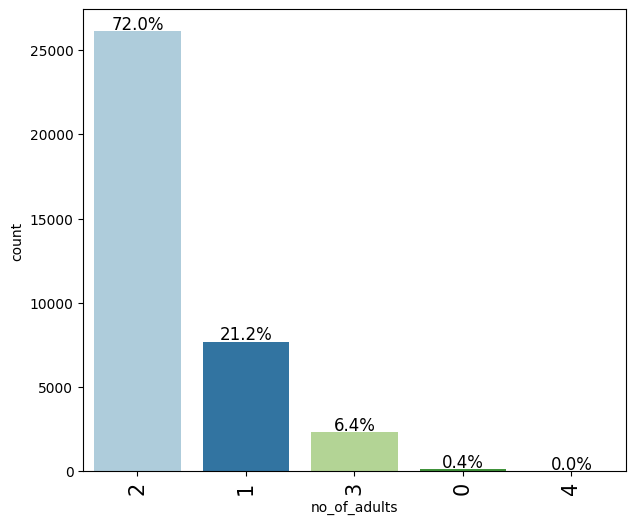

```python
# Calling barplot with percentage
labeled_barplot(df, "no_of_adults", perc=True)
```

- 72% of bookings are for 2 adults.
- There are very few observations with 4 adults.

## Observations on Number of Weekend Nights

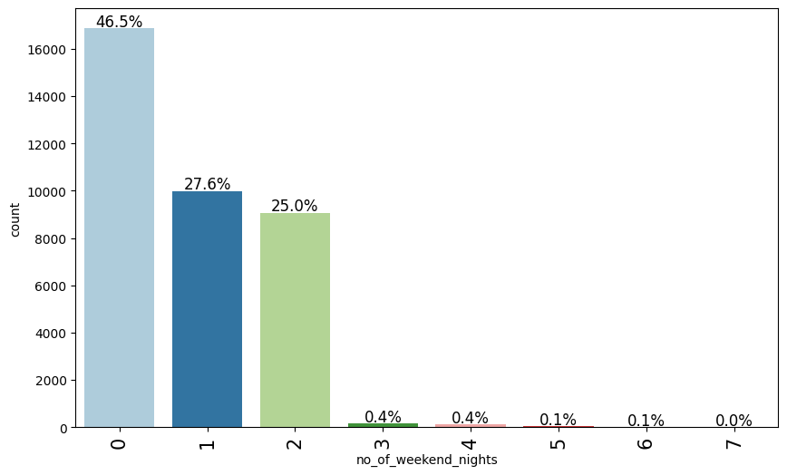

```python
# Calling barplot with percentage
labeled_barplot(df, "no_of_weekend_nights", perc=True)
```

- At least 50% of bookings have at least 1 weekend night booked.
- About 46% of bookings occur only during the week.

## Observations on Number of Week Nights

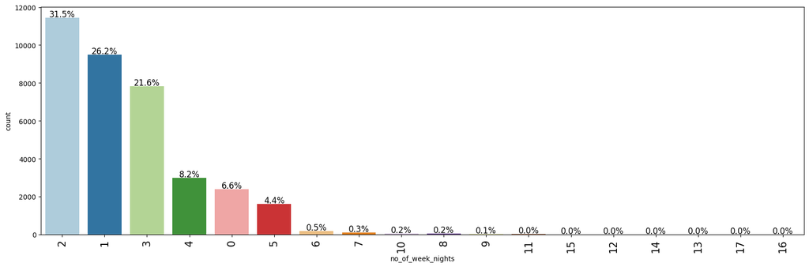

```python
# Calling barplot with percentage
labeled_barplot(df, "no_of_week_nights", perc=True)
```

- At least 31% of bookings have 2 week nights.
- Many bookings greater than 8 days have a percentage close to 0, indicating an outlier of a possible long stay event.

## Observations on Type of Meal Plan

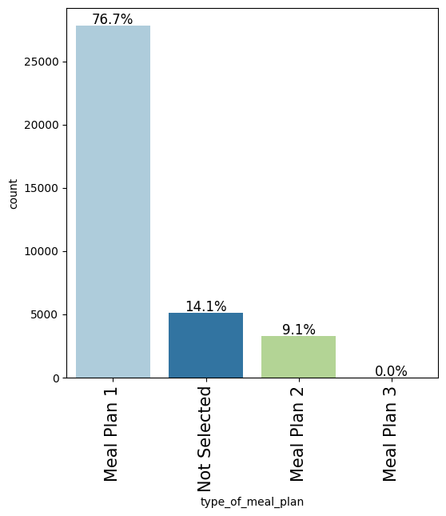

```python
# Calling barplot with percentage
labeled_barplot(df, "type_of_meal_plan", perc=True)
```

- At about 76%, most guests chose the 1st Meal Plan which only included breakfast.
- The majority of the rest did not opt for a meal plan or chose Meal Plan 2 which included Breakfast and 1 other meal.

## Observations on Type of Room Reserved

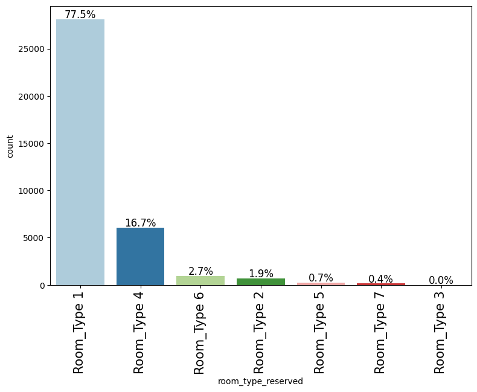

```python
# Calling barplot with percentage
labeled_barplot(df, "room_type_reserved", perc=True)
```

- The most popular room type by far was Room Type 1.
- Very few customers booked Room Types 5, 7 and 3.

## Observations on Arrival Year

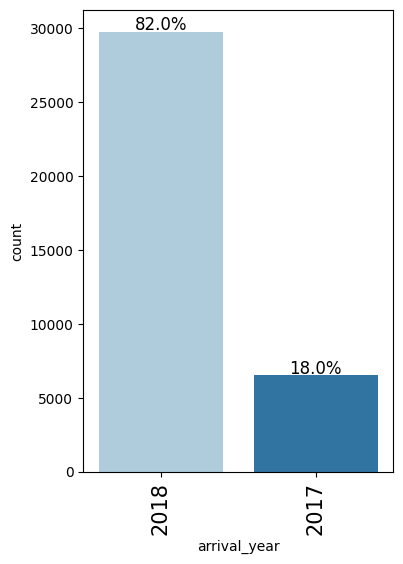

```python
# Calling barplot with percentage
labeled_barplot(df, "arrival_year", perc=True)
```

- 82% of the bookings are from 2018. It's likely the hotel has garnered more business overall since 2017.

### **Bivariate Analysis**

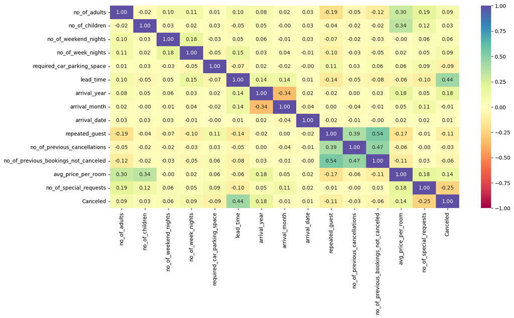

```python
# Calling heatmap of all numeric variables
plt.figure(figsize=(15, 7))
sns.heatmap(df2.corr(numeric_only = True), annot=True, vmin=-1, vmax=1, fmt=".2f", cmap="Spectral")
plt.show()
```

- Repeated guest and number of previous bookings not canceled have a positive correlation with each other which is expected.
- Number of previous cancellations and number of previous bookings not canceled also have a positive correlation.
- Average price per room is positively correlated with number of adults and number of children which is expected.
- Lead time is postively correlated to number of bookings canceled.
- Number of special requests is somewhat negatively correlated to canceled status.

```python
# Function to plot distributions with respect to target


def distribution_plot_wrt_target(data, predictor, target):

    fig, axs = plt.subplots(2, 2, figsize=(12, 10))

    target_uniq = data[target].unique()

    axs[0, 0].set_title("Distribution of target for target=" + str(target_uniq[0]))
    sns.histplot(
        data=data[data[target] == target_uniq[0]],
        x=predictor,
        kde=True,
        ax=axs[0, 0],
        color="teal",
        stat="density",
    )

    axs[0, 1].set_title("Distribution of target for target=" + str(target_uniq[1]))
    sns.histplot(
        data=data[data[target] == target_uniq[1]],
        x=predictor,
        kde=True,
        ax=axs[0, 1],
        color="orange",
        stat="density",
    )

    axs[1, 0].set_title("Boxplot w.r.t target")
    sns.boxplot(data=data, x=target, y=predictor, ax=axs[1, 0], palette="gist_rainbow")

    axs[1, 1].set_title("Boxplot (without outliers) w.r.t target")
    sns.boxplot(
        data=data,
        x=target,
        y=predictor,
        ax=axs[1, 1],
        showfliers=False,
        palette="gist_rainbow",
    )

    plt.tight_layout()
    plt.show()
```

## Canceled vs Lead Time

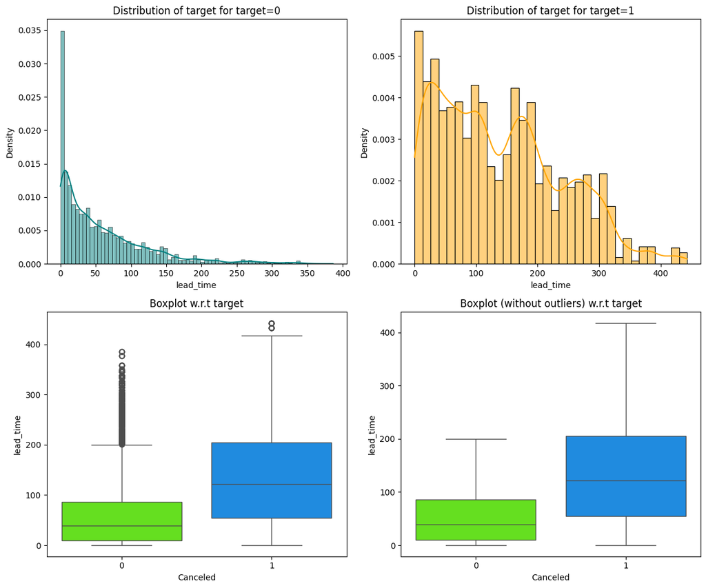

```python
# Calling subplots with respect to 'Canceled'

distribution_plot_wrt_target(df2, "lead_time", "Canceled")
```

- The boxplots indicate bookings with higher lead times are more likely to cancel.
- There are quite a few outliers above the 200 day mark for bookings not canceled.

## Canceled vs Avg Price Per Room

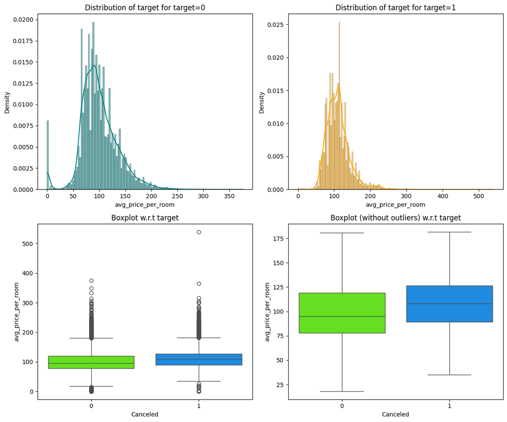

```python
# Calling subplots with respect to 'Canceled'
distribution_plot_wrt_target(df2, "avg_price_per_room", "Canceled")
```

- The third quartile on both sets of boxplots indicate that the more expensive rooms are more likely to cancel.
- There are outliers in both distributions, especially above the ~200 euros mark.

```python
# Function to plot stacked bar chart
def stacked_barplot(data, predictor, target):
    """
    Print the category counts and plot a stacked bar chart

    data: dataframe
    predictor: independent variable
    target: target variable
    """
    count = data[predictor].nunique() # Use the provided data DataFrame
    # Use df2 to get the sorting order based on 'Canceled'
    sorter = df2['Canceled'].value_counts().index[-1]
    tab1 = pd.crosstab(data[predictor], data[target], margins=True).sort_values( # Use the provided data DataFrame
        by=sorter, ascending=False
    )
    print(tab1)
    print("-" * 120)
    tab = pd.crosstab(data[predictor], data[target], normalize="index").sort_values( # Use the provided data DataFrame
        by=sorter, ascending=False
    )
    tab.plot(kind="bar", stacked=True, figsize=(count + 5, 6))
    plt.legend(
        loc="lower left", frameon=False,
    )
    plt.legend(loc="upper left", bbox_to_anchor=(1, 1))
    plt.show()
```

## Number of Weekend Nights vs. Cancelled

```
Canceled                  0      1    All
no_of_weekend_nights
All                   24390  11885  36275
0                     11779   5093  16872
1                      6563   3432   9995
2                      5914   3157   9071
4                        46     83    129
3                        79     74    153
5                         5     29     34
6                         4     16     20
7                         0      1      1
------------------------------------------------------------------------------------------------------------------------
```

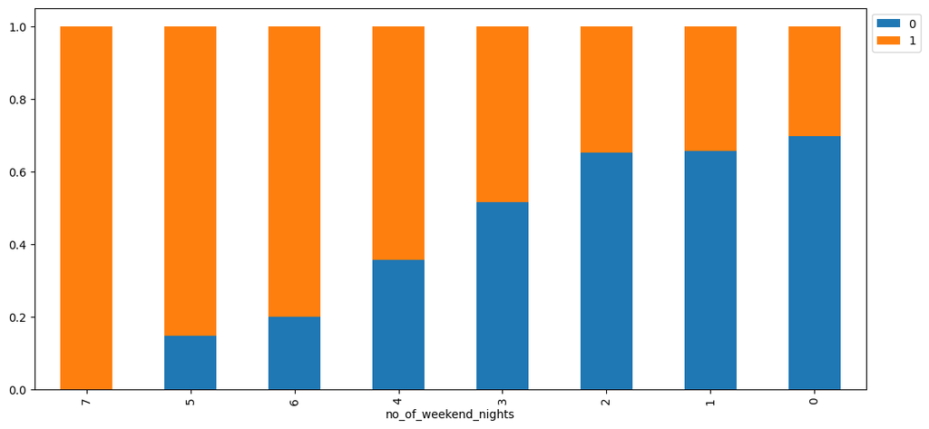

```python
# Calling stacked barplot function
stacked_barplot(df2, "no_of_weekend_nights", "Canceled")
```

- This plot shows that bookings with greater numbers of weekend nights are more likely to cancel.

## Number of Weeknights vs Canceled

```
Canceled               0      1    All
no_of_week_nights
All                24390  11885  36275
2                   7447   3997  11444
3                   5265   2574   7839
1                   6916   2572   9488
4                   1847   1143   2990
0                   1708    679   2387
5                    982    632   1614
6                    101     88    189
10                     9     53     62
7                     61     52    113
8                     30     32     62
9                     13     21     34
11                     3     14     17
15                     2      8     10
12                     2      7      9
13                     0      5      5
14                     3      4      7
16                     0      2      2
17                     1      2      3
------------------------------------------------------------------------------------------------------------------------
```

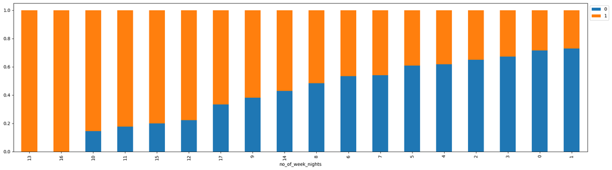

```python
# Calling stacked barplot function
stacked_barplot(df2, "no_of_week_nights", "Canceled")
```

- This plot shows that generally, bookings with more week nights are more likely to cancel. However, this might not perfectly correlate. For example, stays with 9 weeknights have a higher percent canceled than stays with 14 weeknights.

## Market Segment Type vs Canceled

```
Canceled                 0      1    All
market_segment_type
All                  24390  11885  36275
Online               14739   8475  23214
Offline               7375   3153  10528
Corporate             1797    220   2017
Aviation                88     37    125
Complementary          391      0    391
------------------------------------------------------------------------------------------------------------------------
```

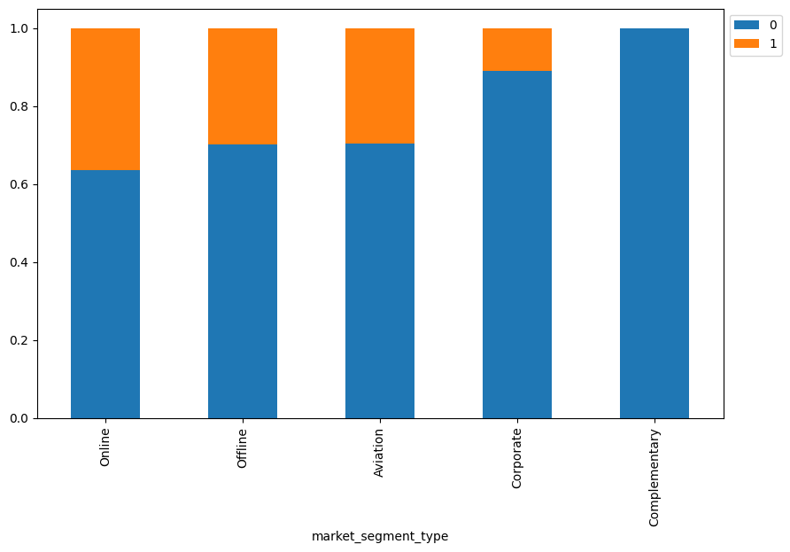

```python
# Calling stacked barplot function
stacked_barplot(df2, "market_segment_type", "Canceled")
```

- The plot shows that guests who booked online are more likely to cancel than any other market segment type.
- Offline and Aviation market segments have about the same rate of cancellation.
- Corporate and complimentary have the least percentage of cancellations.

```
Canceled               0      1    All
type_of_meal_plan
All                24390  11885  36275
Meal Plan 1        19156   8679  27835
Not Selected        3431   1699   5130
Meal Plan 2         1799   1506   3305
Meal Plan 3            4      1      5
------------------------------------------------------------------------------------------------------------------------
```

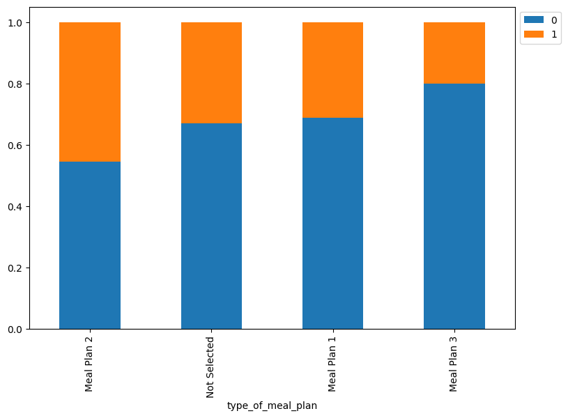

```python
# Calling stacked barplot function
stacked_barplot(df2, "type_of_meal_plan", "Canceled")
```

- This plot shows that guests that ordered Meal Plan 2 were most likely to cancel.
- Not selected and Meal Plan 1 had about the same percentage of cancellations.
- Meal plan 3 had the least amount of cancellations.

### Data Preprocessing

**Missing value treatment (if needed)**

- There are no missing values in the dataset.

**Feature engineering (if needed)**

**Outlier detection and treatment (if needed)**

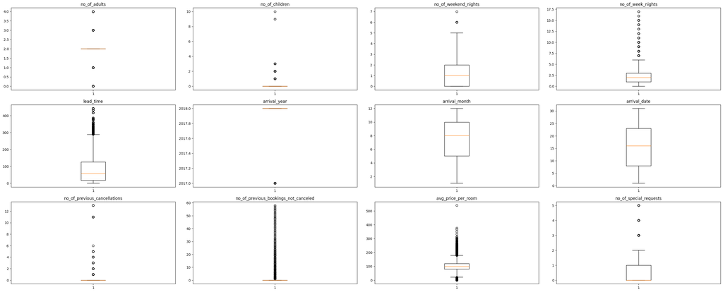

```python
# Selecting all numerical data types
numerical_col = df2.select_dtypes(include=np.number).columns.tolist()
plt.figure(figsize=(30, 20))
# Removing 'Canceled', 'repeated_guest' and 'required_car_parking_space' from list
numerical_col.remove("Canceled")
numerical_col.remove("repeated_guest")
numerical_col.remove("required_car_parking_space")

# Using for loop to generate boxplot for each column
for i, variable in enumerate(numerical_col):
    plt.subplot(5, 4, i + 1)
    plt.boxplot(df2[variable], whis=1.5)
    plt.tight_layout()
    plt.title(variable)

plt.show()
```

```python
# Checking rows with week nights over 16 to verify
df2[df2['no_of_week_nights'] > 16]
```

|  | Booking_ID | no_of_adults | no_of_children | no_of_weekend_nights | no_of_week_nights | type_of_meal_plan | required_car_parking_space | room_type_reserved | lead_time | arrival_year | arrival_month | arrival_date | market_segment_type | repeated_guest | no_of_previous_cancellations | no_of_previous_bookings_not_canceled | avg_price_per_room | no_of_special_requests | booking_status | month_name | Canceled |
| --- | --- | --- | --- | --- | --- | --- | --- | --- | --- | --- | --- | --- | --- | --- | --- | --- | --- | --- | --- | --- | --- |
| 16977 | INN16978 | 1 | 0 | 6 | 17 | Meal Plan 1 | 0 | Room_Type 1 | 9 | 2018 | 1 | 28 | Online | 0 | 0 | 0 | 68.23 | 1 | Not_Canceled | Jan | 0 |
| 19512 | INN19513 | 2 | 0 | 7 | 17 | Meal Plan 1 | 0 | Room_Type 1 | 188 | 2018 | 7 | 4 | Online | 0 | 0 | 0 | 90.95 | 1 | Canceled | Jul | 1 |
| 33019 | INN33020 | 1 | 0 | 6 | 17 | Meal Plan 1 | 0 | Room_Type 5 | 2 | 2018 | 10 | 19 | Corporate | 0 | 0 | 0 | 170.00 | 0 | Canceled | Oct | 1 |

- We will not be removing any outliers as the observations are genuine.

**Preprocessing steps (if needed)**

```python
# Creating a new version of df2 to manipulate
df3 = df2.copy()

# Removing Booking ID since it has no predictive value
df3.drop('Booking_ID', axis=1, inplace=True)

# Checking change made
df3.head()
```

|  | no_of_adults | no_of_children | no_of_weekend_nights | no_of_week_nights | type_of_meal_plan | required_car_parking_space | room_type_reserved | lead_time | arrival_year | arrival_month | arrival_date | market_segment_type | repeated_guest | no_of_previous_cancellations | no_of_previous_bookings_not_canceled | avg_price_per_room | no_of_special_requests | booking_status | month_name | Canceled |
| --- | --- | --- | --- | --- | --- | --- | --- | --- | --- | --- | --- | --- | --- | --- | --- | --- | --- | --- | --- | --- |
| 0 | 2 | 0 | 1 | 2 | Meal Plan 1 | 0 | Room_Type 1 | 224 | 2017 | 10 | 2 | Offline | 0 | 0 | 0 | 65.00 | 0 | Not_Canceled | Oct | 0 |
| 1 | 2 | 0 | 2 | 3 | Not Selected | 0 | Room_Type 1 | 5 | 2018 | 11 | 6 | Online | 0 | 0 | 0 | 106.68 | 1 | Not_Canceled | Nov | 0 |
| 2 | 1 | 0 | 2 | 1 | Meal Plan 1 | 0 | Room_Type 1 | 1 | 2018 | 2 | 28 | Online | 0 | 0 | 0 | 60.00 | 0 | Canceled | Feb | 1 |
| 3 | 2 | 0 | 0 | 2 | Meal Plan 1 | 0 | Room_Type 1 | 211 | 2018 | 5 | 20 | Online | 0 | 0 | 0 | 100.00 | 0 | Canceled | May | 1 |
| 4 | 2 | 0 | 1 | 1 | Not Selected | 0 | Room_Type 1 | 48 | 2018 | 4 | 11 | Online | 0 | 0 | 0 | 94.50 | 0 | Canceled | Apr | 1 |

```python
# Checking columns with object type to create dummies
df3.select_dtypes('object').columns
```

```
Index(['type_of_meal_plan', 'room_type_reserved', 'market_segment_type',
       'booking_status', 'month_name'],
      dtype='object')
```

```python
# Dropping booking_status because Canceled replaces it, month_name because arrival_month provides that info
# Dropping arrival_year due to low variance and predictive value
df3.drop(['booking_status','month_name','arrival_year'], axis=1, inplace=True)
```

```python
# Confirming removal
df3.select_dtypes('object').columns
```

```
Index(['type_of_meal_plan', 'room_type_reserved', 'market_segment_type'], dtype='object')
```

```python
# Get all categorical column names
cat_cols = df3.select_dtypes('object').columns

# One-hot encode them
df3 = pd.get_dummies(df3, columns=cat_cols, drop_first=True)
```

```python
# Checking result
df3.info()
```

```
<class 'pandas.core.frame.DataFrame'>
RangeIndex: 36275 entries, 0 to 36274
Data columns (total 27 columns):
 #   Column                                Non-Null Count  Dtype
---  ------                                --------------  -----
 0   no_of_adults                          36275 non-null  int64
 1   no_of_children                        36275 non-null  int64
 2   no_of_weekend_nights                  36275 non-null  int64
 3   no_of_week_nights                     36275 non-null  int64
 4   required_car_parking_space            36275 non-null  int64
 5   lead_time                             36275 non-null  int64
 6   arrival_month                         36275 non-null  int64
 7   arrival_date                          36275 non-null  int64
 8   repeated_guest                        36275 non-null  int64
 9   no_of_previous_cancellations          36275 non-null  int64
```

[output cut: 19 more lines]

```python
# Dropping these columns as 75% of observations were 0
df3.drop(['no_of_children','required_car_parking_space','no_of_previous_cancellations','no_of_previous_bookings_not_canceled','repeated_guest'], axis=1, inplace=True)
```

## EDA

- It is a good idea to explore the data once again after manipulating it.

```python
# Looking at dataset info
df3.info()
```

```
<class 'pandas.core.frame.DataFrame'>
RangeIndex: 36275 entries, 0 to 36274
Data columns (total 22 columns):
 #   Column                             Non-Null Count  Dtype
---  ------                             --------------  -----
 0   no_of_adults                       36275 non-null  int64
 1   no_of_weekend_nights               36275 non-null  int64
 2   no_of_week_nights                  36275 non-null  int64
 3   lead_time                          36275 non-null  int64
 4   arrival_month                      36275 non-null  int64
 5   arrival_date                       36275 non-null  int64
 6   avg_price_per_room                 36275 non-null  float64
 7   no_of_special_requests             36275 non-null  int64
 8   Canceled                           36275 non-null  int64
 9   type_of_meal_plan_Meal Plan 2      36275 non-null  bool
 10  type_of_meal_plan_Meal Plan 3      36275 non-null  bool
 11  type_of_meal_plan_Not Selected     36275 non-null  bool
 12  room_type_reserved_Room_Type 2     36275 non-null  bool
 13  room_type_reserved_Room_Type 3     36275 non-null  bool
 14  room_type_reserved_Room_Type 4     36275 non-null  bool
 15  room_type_reserved_Room_Type 5     36275 non-null  bool
 16  room_type_reserved_Room_Type 6     36275 non-null  bool
 17  room_type_reserved_Room_Type 7     36275 non-null  bool
 18  market_segment_type_Complementary  36275 non-null  bool
 19  market_segment_type_Corporate      36275 non-null  bool
 20  market_segment_type_Offline        36275 non-null  bool
 21  market_segment_type_Online         36275 non-null  bool
dtypes: bool(13), float64(1), int64(8)
memory usage: 2.9 MB
```

- The dataset now contains boolean types instead of object for categorical variables.

```python
# Looking at new statistical summary
df3.describe().T
```

|  | count | mean | std | min | 25% | 50% | 75% | max |
| --- | --- | --- | --- | --- | --- | --- | --- | --- |
| no_of_adults | 36275.0 | 1.844962 | 0.518715 | 0.0 | 2.0 | 2.00 | 2.0 | 4.0 |
| no_of_weekend_nights | 36275.0 | 0.810724 | 0.870644 | 0.0 | 0.0 | 1.00 | 2.0 | 7.0 |
| no_of_week_nights | 36275.0 | 2.204300 | 1.410905 | 0.0 | 1.0 | 2.00 | 3.0 | 17.0 |
| lead_time | 36275.0 | 85.232557 | 85.930817 | 0.0 | 17.0 | 57.00 | 126.0 | 443.0 |
| arrival_month | 36275.0 | 7.423653 | 3.069894 | 1.0 | 5.0 | 8.00 | 10.0 | 12.0 |
| arrival_date | 36275.0 | 15.596995 | 8.740447 | 1.0 | 8.0 | 16.00 | 23.0 | 31.0 |
| avg_price_per_room | 36275.0 | 103.423539 | 35.089424 | 0.0 | 80.3 | 99.45 | 120.0 | 540.0 |
| no_of_special_requests | 36275.0 | 0.619655 | 0.786236 | 0.0 | 0.0 | 0.00 | 1.0 | 5.0 |
| Canceled | 36275.0 | 0.327636 | 0.469358 | 0.0 | 0.0 | 0.00 | 1.0 | 1.0 |

- The statistical data has remained consistent after preprocessing.

```python
# Running a correlation check of all variables in newest version
corr = df3.corr(numeric_only=True)['Canceled'].sort_values(ascending=False)
corr.head(15)
```

|  | Canceled |
| --- | --- |
| Canceled | 1.000000 |
| lead_time | 0.438538 |
| avg_price_per_room | 0.142569 |
| market_segment_type_Online | 0.106362 |
| no_of_week_nights | 0.092996 |
| no_of_adults | 0.086920 |
| type_of_meal_plan_Meal Plan 2 | 0.086370 |
| no_of_weekend_nights | 0.061563 |
| room_type_reserved_Room_Type 6 | 0.032652 |
| room_type_reserved_Room_Type 4 | 0.013309 |
| arrival_date | 0.010629 |
| type_of_meal_plan_Not Selected | 0.003072 |
| room_type_reserved_Room_Type 2 | 0.000548 |
| room_type_reserved_Room_Type 3 | -0.001241 |
| type_of_meal_plan_Meal Plan 3 | -0.003193 |

**dtype:** float64

- The correlation check shows lead time, average price of room and Online market segment types have the highest positive correlation with canceled bookings

**Preparing data for modeling**

```python
# Identifying the independent and dependent variables
X = df3.drop(["Canceled"], axis=1)
Y = df3["Canceled"]

# adding a constant to the independent variables
X = sm.add_constant(X)

# creating dummy variables
X = pd.get_dummies(X, drop_first=True)
X = X.astype(float)

# splitting data in train and test sets
X_train, X_test, y_train, y_test = train_test_split(
    X, Y, test_size=0.30, random_state=1
)
```

```python
# Printing training/test set stats
print("Shape of Training set : ", X_train.shape)
print("Shape of test set : ", X_test.shape)
print("Percentage of classes in training set:")
print(y_train.value_counts(normalize=True))
print("Percentage of classes in test set:")
print(y_test.value_counts(normalize=True))
```

```
Shape of Training set :  (25392, 22)
Shape of test set :  (10883, 22)
Percentage of classes in training set:
Canceled
0    0.670644
1    0.329356
Name: proportion, dtype: float64
Percentage of classes in test set:
Canceled
0    0.676376
1    0.323624
Name: proportion, dtype: float64
```

## Checking Multicollinearity

- In order to make statistical inferences from a logistic regression model, it is important to ensure that there is no multicollinearity present in the data.

```python
# Creating variance inflation factor series
vif_series = pd.Series(
    [variance_inflation_factor(X_train.values, i) for i in range(X_train.shape[1])],
    index=X_train.columns,
    dtype=float,
)
print("Series before feature selection: \n\n{}\n".format(vif_series))
```

```
Series before feature selection:

const                                327.696650
no_of_adults                           1.320588
no_of_weekend_nights                   1.066711
no_of_week_nights                      1.092214
lead_time                              1.243747
arrival_month                          1.050183
arrival_date                           1.006114
avg_price_per_room                     1.884585
no_of_special_requests                 1.225517
type_of_meal_plan_Meal Plan 2          1.202719
type_of_meal_plan_Meal Plan 3          1.024471
type_of_meal_plan_Not Selected         1.231913
room_type_reserved_Room_Type 2         1.036961
room_type_reserved_Room_Type 3         1.003093
room_type_reserved_Room_Type 4         1.351958
room_type_reserved_Room_Type 5         1.026786
room_type_reserved_Room_Type 6         1.277572
room_type_reserved_Room_Type 7         1.090393
market_segment_type_Complementary      4.477538
market_segment_type_Corporate         16.788857
market_segment_type_Offline           63.797559
market_segment_type_Online            70.862460
dtype: float64
```

**Dropping `market_segment_type_Online`**

```python
X_train1 = X_train.drop("market_segment_type_Online", axis=1)
vif_series2 = pd.Series(
    [variance_inflation_factor(X_train2.values, i) for i in range(X_train1.shape[1])],
    index=X_train1.columns,
)
print("Series before feature selection: \n\n{}\n".format(vif_series2))
```

```
Series before feature selection:

const                                4.284203e+07
no_of_adults                         1.340483e+00
no_of_weekend_nights                 1.076389e+00
no_of_week_nights                    1.101222e+00
lead_time                            1.532776e+00
arrival_month                        1.553918e+00
arrival_date                         1.013491e+00
avg_price_per_room                   2.452742e+00
no_of_special_requests               1.227897e+00
type_of_meal_plan_Meal Plan 2        1.290015e+00
type_of_meal_plan_Meal Plan 3        1.024808e+00
type_of_meal_plan_Not Selected       1.273874e+00
room_type_reserved_Room_Type 2       1.041333e+00
room_type_reserved_Room_Type 3       1.003588e+00
room_type_reserved_Room_Type 4       1.356710e+00
room_type_reserved_Room_Type 5       1.028262e+00
room_type_reserved_Room_Type 6       1.324762e+00
room_type_reserved_Room_Type 7       1.096794e+00
market_segment_type_Complementary    1.342960e+00
market_segment_type_Corporate        1.300151e+00
market_segment_type_Offline          1.637286e+00
dtype: float64
```

- Multicollinearity has been fixed in the market segment type column after dropping `market_segment_type_Online`.

## Building a Logistic Regression model

```python
# defining a function to compute different metrics to check performance of a classification model built using statsmodels
def model_performance_classification_statsmodels(
    model, predictors, target, threshold=0.5
):
    """
    Function to compute different metrics to check classification model performance

    model: classifier
    predictors: independent variables
    target: dependent variable
    threshold: threshold for classifying the observation as class 1
    """

    # checking which probabilities are greater than threshold
    pred_temp = model.predict(predictors) > threshold
    # rounding off the above values to get classes
    pred = np.round(pred_temp)

    acc = accuracy_score(target, pred)  # to compute Accuracy
    recall = recall_score(target, pred)  # to compute Recall
    precision = precision_score(target, pred)  # to compute Precision
    f1 = f1_score(target, pred)  # to compute F1-score

    # creating a dataframe of metrics
    df_perf = pd.DataFrame(
        {"Accuracy": acc, "Recall": recall, "Precision": precision, "F1": f1,},
        index=[0],
    )

    return df_perf
```

```python
# Fitting logistic regression model
logit2 = sm.Logit(y_train, X_train2.astype(float))
lg2 = logit2.fit(disp=False)

print("Training performance:")
model_performance_classification_statsmodels(lg2, X_train2, y_train)
```

[output not shown]

- We are getting the singular matrix error which could indicate that there are still multicollinear variables present.

```python
# Checking for constant or duplicate columns
(X_train2.nunique() == 1).sum()
X_train2.loc[:, X_train2.nunique() == 1].head()
```

|  | const |
| --- | --- |
| 13662 | 1.0 |
| 26641 | 1.0 |
| 17835 | 1.0 |
| 21485 | 1.0 |
| 5670 | 1.0 |

```python
# Checking for perfect separation
for col in X_train2.columns:
    unique_vals = y_train.groupby(X_train2[col]).nunique()
    if unique_vals.min() == 1:
        print(f"Perfect separation detected in column: {col}")
```

```
Perfect separation detected in column: no_of_week_nights
Perfect separation detected in column: lead_time
Perfect separation detected in column: avg_price_per_room
Perfect separation detected in column: no_of_special_requests
Perfect separation detected in column: market_segment_type_Complementary
```

```python
# Looking at how many cancellations Complementary has
df3.groupby('market_segment_type_Complementary')['Canceled'].value_counts()
```

| market_segment_type_Complementary | Canceled | count |
| --- | --- | --- |
| False | 0 | 23999 |
|  | 1 | 11885 |
| True | 0 | 391 |

**dtype:** int64

- Market segment type Complementary has 0 cancellations and therefore is creating perfect separation which causes a singular matrix.

**Removing `market_segment_type_Complementary`**

```python
# Dropping Complementary market segment type
X_train3 = X_train.drop("market_segment_type_Complementary", axis=1)
vif_series3 = pd.Series(
    [variance_inflation_factor(X_train3.values, i) for i in range(X_train3.shape[1])],
    index=X_train3.columns,
)
print("Series before feature selection: \n\n{}\n".format(vif_series2))
```

```
Series before feature selection:

const                                4.284203e+07
no_of_adults                         1.340483e+00
no_of_weekend_nights                 1.076389e+00
no_of_week_nights                    1.101222e+00
lead_time                            1.532776e+00
arrival_month                        1.553918e+00
arrival_date                         1.013491e+00
avg_price_per_room                   2.452742e+00
no_of_special_requests               1.227897e+00
type_of_meal_plan_Meal Plan 2        1.290015e+00
type_of_meal_plan_Meal Plan 3        1.024808e+00
type_of_meal_plan_Not Selected       1.273874e+00
room_type_reserved_Room_Type 2       1.041333e+00
room_type_reserved_Room_Type 3       1.003588e+00
room_type_reserved_Room_Type 4       1.356710e+00
room_type_reserved_Room_Type 5       1.028262e+00
room_type_reserved_Room_Type 6       1.324762e+00
room_type_reserved_Room_Type 7       1.096794e+00
market_segment_type_Complementary    1.342960e+00
market_segment_type_Corporate        1.300151e+00
market_segment_type_Offline          1.637286e+00
dtype: float64
```

```python
# Fitting the logistic regression function
logit3 = sm.Logit(y_train, X_train3.astype(float))
lg3 = logit3.fit(disp=False)
```

## Model performance evaluation

```python
# Calling model performance from statsmodels
print("Training performance:")
model_performance_classification_statsmodels(lg3, X_train3, y_train)
```

```
Training performance:
```

|  | Accuracy | Recall | Precision | F1 |
| --- | --- | --- | --- | --- |
| 0 | 0.800016 | 0.617721 | 0.733078 | 0.670474 |

- The logistic regression training model achieved an accuracy of 80% with a recall of 61%, a precision of 73% and F1 score at 0.67. The results indicate the model works reasonably well at predicting cancellations with a good balance between identifying true cancellations and minimizing false positives.

## Final Model Summary

```python
# Naming and running test model
X_test3 = X_test[X_train3.columns]

# Predicting test results
y_pred_prob = lg3.predict(X_test3)
y_pred = (y_pred_prob >= 0.5).astype(int)
```

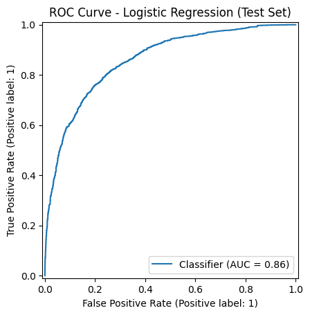

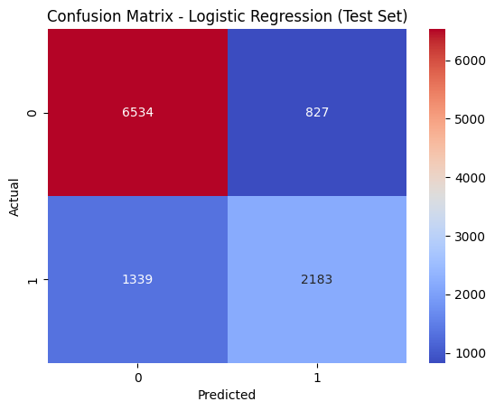

```python
# Importing ROC Curve
from sklearn.metrics import RocCurveDisplay

# ROC Curve
RocCurveDisplay.from_predictions(y_test, y_pred_prob)
plt.title("ROC Curve - Logistic Regression (Test Set)")
plt.show()

# Confusion Matrix Heatmap
sns.heatmap(confusion_matrix(y_test, y_pred), annot=True, fmt='d', cmap='coolwarm')
plt.xlabel("Predicted")
plt.ylabel("Actual")
plt.title("Confusion Matrix - Logistic Regression (Test Set)")
plt.show()
```

```python
# Calling functions from sklearn.metrics to compute scores
from sklearn.metrics import accuracy_score, precision_score, recall_score, f1_score, roc_auc_score, confusion_matrix, classification_report

print("Test Performance:")
print("Accuracy:", accuracy_score(y_test, y_pred))
print("Precision:", precision_score(y_test, y_pred))
print("Recall:", recall_score(y_test, y_pred))
print("F1:", f1_score(y_test, y_pred))
print("ROC-AUC:", roc_auc_score(y_test, y_pred_prob))
print("\nConfusion Matrix:\n", confusion_matrix(y_test, y_pred))
```

```
Test Performance:
Accuracy: 0.80097399614077
Precision: 0.725249169435216
Recall: 0.6198182850653038
F1: 0.6684017146356399
ROC-AUC: 0.8600012682522441

Confusion Matrix:
 [[6534  827]
 [1339 2183]]
```

*The logistic regression model showed a strong predictive performance on the test set with an AUC of 0.86 and overall accuracy of 80%. The model correctly identified 62% of actual cancellations while maintaining a precision of 73%. This indicates the predictions are reliable with relatively few false positives. The results suggest the model can effectively support the hotel in predicting booking cancellations reducing revenue loss.

## Building a Decision Tree model

```python
# Building decision tree model
model = DecisionTreeClassifier(criterion="gini", random_state=1)
model.fit(X_train3, y_train)
```

```
DecisionTreeClassifier(random_state=1)
```

```python
# defining a function to compute different metrics to check performance of a classification model built using sklearn
def model_performance_classification_sklearn(model, predictors, target):
    """
    Function to compute different metrics to check classification model performance

    model: classifier
    predictors: independent variables
    target: dependent variable
    """

    # predicting using the independent variables
    pred = model.predict(predictors)

    acc = accuracy_score(target, pred)  # to compute Accuracy
    recall = recall_score(target, pred)  # to compute Recall
    precision = precision_score(target, pred)  # to compute Precision
    f1 = f1_score(target, pred)  # to compute F1-score

    # creating a dataframe of metrics
    df_perf = pd.DataFrame(
        {"Accuracy": acc, "Recall": recall, "Precision": precision, "F1": f1,},
        index=[0],
    )

    return df_perf
```

```python
# defining a function to create confusion matrix to check performance
def confusion_matrix_sklearn(model, predictors, target):
    """
    To plot the confusion_matrix with percentages

    model: classifier
    predictors: independent variables
    target: dependent variable
    """
    y_pred = model.predict(predictors)
    cm = confusion_matrix(target, y_pred)
    labels = np.asarray(
        [
            ["{0:0.0f}".format(item) + "\n{0:.2%}".format(item / cm.flatten().sum())]
            for item in cm.flatten()
        ]
    ).reshape(2, 2)

    plt.figure(figsize=(6, 4))
    sns.heatmap(cm, annot=labels, fmt="")
    plt.ylabel("True label")
    plt.xlabel("Predicted label")
```

```python
# Checking performance on training set
decision_tree_perf_train = model_performance_classification_sklearn(
    model, X_train3, y_train
)
decision_tree_perf_train
```

|  | Accuracy | Recall | Precision | F1 |
| --- | --- | --- | --- | --- |
| 0 | 0.994014 | 0.98601 | 0.995773 | 0.990868 |

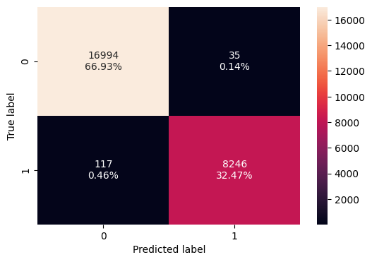

```python
# Creating confusion matrix
confusion_matrix_sklearn(model, X_train3, y_train)
```

```python
# Checking decision tree performance on testing set
decision_tree_perf_test = model_performance_classification_sklearn(
    model, X_test3, y_test
)
decision_tree_perf_test
```

|  | Accuracy | Recall | Precision | F1 |
| --- | --- | --- | --- | --- |
| 0 | 0.865938 | 0.801249 | 0.788048 | 0.794594 |

```python
# Creating list of column names from X_train3
feature_names = list(X_train3.columns)
print(feature_names)
```

```
['const', 'no_of_adults', 'no_of_weekend_nights', 'no_of_week_nights', 'lead_time', 'arrival_month', 'arrival_date', 'avg_price_per_room', 'no_of_special_requests', 'type_of_meal_plan_Meal Plan 2', 'type_of_meal_plan_Meal Plan 3', 'type_of_meal_plan_Not Selected', 'room_type_reserved_Room_Type 2', '…
```

[figure not shown]

```python
# Creating decision tree visual
plt.figure(figsize=(20, 30))

out = tree.plot_tree(
    model,
    feature_names=feature_names,
    filled=True,
    fontsize=9,
    node_ids=True,
    class_names=True,
)
for o in out:
    arrow = o.arrow_patch
    if arrow is not None:
        arrow.set_edgecolor("black")
        arrow.set_linewidth(1)
plt.show()
```

## Do we need to prune the tree?

- The decison tree classified almost every training booking perfectly. While seemingly ideal, this is too perfect for real world data and indicates overfitting. The model simply memorized the training data without learning generalized patterns. Without pruning or limitation, this would lower predictive accuracy.

[figure not shown]

```python
# Calling model feature importances
importances = model.feature_importances_
indices = np.argsort(importances)

plt.figure(figsize=(10, 8))
plt.title("Feature Importances")
plt.barh(range(len(indices)), importances[indices], color="teal", align="center")
plt.yticks(range(len(indices)), [feature_names[i] for i in indices])
plt.xlabel("Relative Importance")
plt.show()
```

- Lead time, average price per room and offline market segment type were the 3 most important features to focus on.

```python
# Guards to reduce overfitting
base_params = dict(min_samples_leaf=10, min_samples_split=20, random_state=1)

# Getting pruning path
big_tree = DecisionTreeClassifier(**base_params)  # max_depth=None
big_tree.fit(X_train3, y_train)
alphas = big_tree.cost_complexity_pruning_path(X_train3, y_train).ccp_alphas

# subsample alphas
alphas = np.unique(np.quantile(alphas, np.linspace(0, 1, 20)))

# CV pick best alpha using F1
cv = StratifiedKFold(n_splits=3, shuffle=True, random_state=1)
scores = []
for a in alphas:
    clf = DecisionTreeClassifier(ccp_alpha=a, **base_params)
    s = cross_val_score(clf, X_train3, y_train, cv=cv, scoring='f1', n_jobs=-1)
    scores.append(s.mean())

best_alpha = alphas[int(np.argmax(scores))]
pruned_tree = DecisionTreeClassifier(ccp_alpha=best_alpha, **base_params).fit(X_train3, y_train)

# evaluate on test
from sklearn.metrics import accuracy_score, precision_score, recall_score, f1_score, roc_auc_score
y_pred  = pruned_tree.predict(X_test3)
y_prob  = pruned_tree.predict_proba(X_test3)[:,1]

print("Test Accuracy:", accuracy_score(y_test, y_pred))
print("Test Precision:", precision_score(y_test, y_pred))
print("Test Recall:", recall_score(y_test, y_pred))
print("Test F1:", f1_score(y_test, y_pred))
print("Test ROC-AUC:", roc_auc_score(y_test, y_prob))
```

```
Test Accuracy: 0.8705320224202885
Test Precision: 0.815090963316433
Test Recall: 0.7759795570698467
Test F1: 0.7950545454545455
Test ROC-AUC: 0.9232675955920058
```

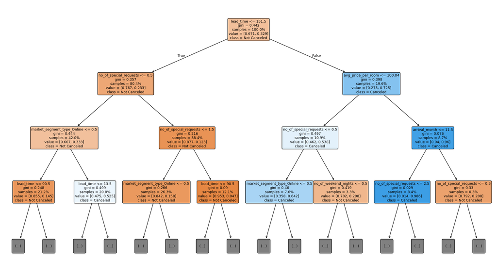

```python
# Visualizing pruned tree
model_to_plot = pruned_tree

plt.figure(figsize=(18, 10))
tree.plot_tree(
    model_to_plot,
    feature_names=X_test3.columns,
    class_names=['Not Canceled', 'Canceled'],
    filled=True,
    rounded=True,
    fontsize=9,
    proportion=True,
    max_depth=3
)
plt.tight_layout()
plt.show()
```

```python
print(tree.export_text(pruned_tree, feature_names=feature_names, show_weights=True))
```

```
|--- lead_time <= 151.50
|   |--- no_of_special_requests <= 0.50
|   |   |--- market_segment_type_Online <= 0.50
|   |   |   |--- lead_time <= 90.50
|   |   |   |   |--- avg_price_per_room <= 201.50
|   |   |   |   |   |--- no_of_weekend_nights <= 0.50
|   |   |   |   |   |   |--- market_segment_type_Offline <= 0.50
|   |   |   |   |   |   |   |--- weights: [720.00, 87.00] class: 0
|   |   |   |   |   |   |--- market_segment_type_Offline >  0.50
|   |   |   |   |   |   |   |--- weights: [1609.00, 0.00] class: 0
|   |   |   |   |   |--- no_of_weekend_nights >  0.50
|   |   |   |   |   |   |--- lead_time <= 68.50
|   |   |   |   |   |   |   |--- no_of_weekend_nights <= 3.50
|   |   |   |   |   |   |   |   |--- lead_time <= 1.50
|   |   |   |   |   |   |   |   |   |--- arrival_date <= 27.50
|   |   |   |   |   |   |   |   |   |   |--- weights: [95.00, 5.00] class: 0
|   |   |   |   |   |   |   |   |   |--- arrival_date >  27.50
|   |   |   |   |   |   |   |   |   |   |--- arrival_month <= 2.50
|   |   |   |   |   |   |   |   |   |   |   |--- weights: [2.00, 33.00] class: 1
|   |   |   |   |   |   |   |   |   |   |--- arrival_month >  2.50
|   |   |   |   |   |   |   |   |   |   |   |--- weights: [10.00, 2.00] class: 0
|   |   |   |   |   |   |   |   |--- lead_time >  1.50
|   |   |   |   |   |   |   |   |   |--- weights: [1179.00, 97.00] class: 0
|   |   |   |   |   |   |   |--- no_of_weekend_nights >  3.50
|   |   |   |   |   |   |   |   |--- weights: [2.00, 10.00] class: 1
|   |   |   |   |   |   |--- lead_time >  68.50
|   |   |   |   |   |   |   |--- avg_price_per_room <= 99.98
|   |   |   |   |   |   |   |   |--- weights: [140.00, 25.00] class: 0
|   |   |   |   |   |   |   |--- avg_price_per_room >  99.98
|   |   |   |   |   |   |   |   |--- no_of_adults <= 1.50
|   |   |   |   |   |   |   |   |   |--- weights: [1.00, 52.00] class: 1
|   |   |   |   |   |   |   |   |--- no_of_adults >  1.50
|   |   |   |   |   |   |   |   |   |--- arrival_date <= 23.50
|   |   |   |   |   |   |   |   |   |   |--- weights: [28.00, 5.00] class: 0
|   |   |   |   |   |   |   |   |   |--- arrival_date >  23.50
|   |   |   |   |   |   |   |   |   |   |--- weights: [4.00, 24.00] class: 1
|   |   |   |   |--- avg_price_per_room >  201.50
|   |   |   |   |   |--- weights: [2.00, 17.00] class: 1
|   |   |   |--- lead_time >  90.50
|   |   |   |   |--- lead_time <= 117.50
```

[output cut: 237 more lines]

```
|   |   |   |   |--- market_segment_type_Online <= 0.50
|   |   |   |   |   |--- weights: [151.00, 5.00] class: 0
|   |   |   |   |--- market_segment_type_Online >  0.50
|   |   |   |   |   |--- weights: [336.00, 96.00] class: 0
|   |--- avg_price_per_room >  100.04
|   |   |--- arrival_month <= 11.50
|   |   |   |--- no_of_special_requests <= 2.50
|   |   |   |   |--- weights: [0.00, 2108.00] class: 1
|   |   |   |--- no_of_special_requests >  2.50
|   |   |   |   |--- weights: [31.00, 0.00] class: 0
|   |   |--- arrival_month >  11.50
|   |   |   |--- no_of_special_requests <= 0.50
|   |   |   |   |--- weights: [47.00, 0.00] class: 0
|   |   |   |--- no_of_special_requests >  0.50
|   |   |   |   |--- weights: [10.00, 15.00] class: 1
```

## Model Performance Comparison and Conclusions

```python
import pandas as pd
from sklearn.metrics import accuracy_score, precision_score, recall_score, f1_score
from sklearn.tree import DecisionTreeClassifier

# -------------------------------------------------
# 0) Fit models (skip/modify if yours are already fit)
# -------------------------------------------------
# Original (unpruned) tree
try:
    orig_tree
except NameError:
    orig_tree = DecisionTreeClassifier(random_state=1)  # vanilla tree
    orig_tree.fit(X_train3, y_train)

# pruned_tree should already be trained from your pruning step


# -------------------------------------------------
# 1) Helper to compute metrics
# -------------------------------------------------
def eval_clf(clf, X, y):
    y_pred = clf.predict(X)
    return pd.Series({
        "Accuracy":  accuracy_score(y, y_pred),
        "Recall":    recall_score(y, y_pred, zero_division=0),
        "Precision": precision_score(y, y_pred, zero_division=0),
        "F1":        f1_score(y, y_pred, zero_division=0),
    })

def compare_models(models, names, X, y, round_to=4):
    out = pd.concat([eval_clf(m, X, y) for m in models], axis=1)
    out.columns = names
    return out.T.round(round_to)


# -------------------------------------------------
# 2) TRAIN set comparison
# -------------------------------------------------
models = [orig_tree, pruned_tree]
names  = ["Decision Tree (Original)", "Decision Tree (Post-Pruned)"]

models_train_comp_df = compare_models(models, names, X_train3, y_train)
print("Train set performance comparison:")
display(models_train_comp_df)

# -------------------------------------------------
# 3) TEST set comparison
# -------------------------------------------------
models_test_comp_df = compare_models(models, names, X_test3, y_test)
print("Test set performance comparison:")
display(models_test_comp_df)
```

```
Train set performance comparison:
```

|  | Accuracy | Recall | Precision | F1 |
| --- | --- | --- | --- | --- |
| Decision Tree (Original) | 0.9940 | 0.986 | 0.9958 | 0.9909 |
| Decision Tree (Post-Pruned) | 0.8727 | 0.782 | 0.8226 | 0.8018 |

```
Test set performance comparison:
```

|  | Accuracy | Recall | Precision | F1 |
| --- | --- | --- | --- | --- |
| Decision Tree (Original) | 0.8659 | 0.8012 | 0.7880 | 0.7946 |
| Decision Tree (Post-Pruned) | 0.8705 | 0.7760 | 0.8151 | 0.7951 |

- **Training Set:** The original decision tree demonstrated extremely high performance (Accuracy ≈ 0.994, Recall ≈ 0.986, Precision ≈ 0.996, F1 ≈ 0.991). These numbers were too perfect, indicating overfitting the training data. The post-pruned tree shows lower scores (Accuracy ≈ 0.872, Recall ≈ 0.782, Precision ≈ 0.823, F1 ≈ 0.802), which are more realistic and expected after pruning.
- **Test Set:** The original tree declined sharply in performance on testing data (Accuracy ≈ 0.866, Recall ≈ 0.801, Precision ≈ 0.788, F1 ≈ 0.795), confirming that overfitting compromised accurate predictions. The post-pruned tree mildly improved overall predictions (Accuracy ≈ 0.871, Recall ≈ 0.776, Precision ≈ 0.815, F1 ≈ 0.795). These balanced metrics indicate more stability and interpretability while maintaining comparable predictive power.
- **Conclusion:** Pruning reduced model complexity and overfitting without too much accuracy loss. The post-pruned tree generalizes better and is the preferred model for predicting hotel booking cancellations.

### Actionable Insights and Recommendations

**What profitable policies for cancellations and refunds can the hotel adopt?**

- Installing cancellation fees or asking for higher deposits for bookings with greater lead times (higher risk)
- For customers predicted more likely to cancel, they could offer a non-refundable discount rate to retain revenue
- For moderate to low risk customers, the hotel could offer credit based rebooking instead of full refunds

**What other recommedations would you suggest to the hotel?**

- The hotel could send out confirmation emails to high risk customers which would reduce accidental cancellations
- They could also offer loyalty points or perks to repeated customers to encourage retention

```python
!pip install nbconvert
```

```python
from google.colab import drive
drive.mount('/content/drive')

from google.colab import files

notebook_name = "/content/drive/MyDrive/Content/ARodriguez_Project_SLC_DSBA_INNHotels_FullCode.ipynb"
html_output_name = notebook_name.replace('.ipynb', '.html')

get_ipython().system(f'jupyter nbconvert --to html "{notebook_name}"')
files.download(html_output_name)
```

[output not shown]

[output cut: 136 more lines]

[output not shown]

[output not shown]